← Voltar ao Portal

[figure not shown]

Programa 420

# Síntese Avaliativa do Desempenho dos Programas do PPA Bahia 2024–2027

# **1 - Desempenho Global do Programa**

Este documento apresenta uma Síntese Avaliativa do Desempenho do Programa do Plano Plurianual - PPA 2024- 2027, trazendo uma visão estratégica dos seus resultados, de forma sintética, transparente e colaborativa. Serão levados em consideração o Indicador Sintético de Desempenho do Programa (ISDP), a evolução dos Indicadores de Programa, a eficácia das metas dos Indicadores de Compromisso, o desempenho da execução orçamentária-financeira e da execução física das Ações orçamentárias. O ISDP é uma síntese dessas quatro dimensões, destacando o desempenho do programa em relação aos resultados obtidos e aos esforços despendidos.  
Adicionalmente, são apresentados os principais resultados alcançados, evidenciando os avanços e conformidades dos cinco programas com melhores resultados, além das oportunidades de melhoria dos cinco, com menores resultados. Enquanto neste documento a análise abrange o programa e seus componentes de maneira sintética, nos demais relatórios, a análise detalhada evidencia o comportamento dos componentes do PPA por programas e por órgãos (https://www.ba.gov.br/seplan/monitoramento-e-avaliacao/avaliacao-do-ppa). Além desta Síntese, o [Painel BI - Boletim de Avanços e Oportunidades de Melhoria](https://app.powerbi.com/view?r=eyJrIjoiN2Q0ODliNDItZDFjZi00MGM1LTliNGEtODVmZDAwZTQ1OGEyIiwidCI6IjRjZDgzNWY0LTU0NDAtNDA4Zi05M2EzLTk3NWZjMTdjMzg0YSIsImMiOjR9) oferece informações organizadas em uma perspectiva estratégica do desempenho consolidado dos programas, detalhando, no entanto, cada componente avaliado. A análise nesta seção engloba o programa e seus componentes conforme segue:

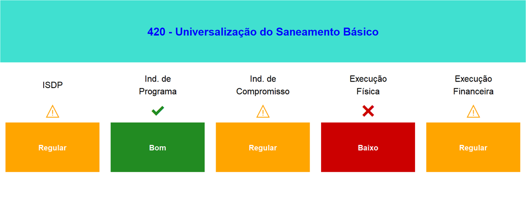

# **2 - Avanços e Conformidades no Programa**

**Indicadores de Programa:** No programa 420 - Universalização do Saneamento Básico, 83,3% dos indicadores apresentaram evolução positiva. O indicador 2215, que mede a proporção de municípios com disposição final ambientalmente adequada de resíduos sólidos urbanos, teve uma evolução de 27,31%. Essa melhoria pode ser explicada pelos dados coletados no Relatório dos Serviços de Limpeza Urbana e Manejo de Resíduos Sólidos de 2025, que consideraram tanto o aterro controlado quanto os lixões. Vale ressaltar também o indicador 2212, que mede a proporção de domicílios rurais com destinação inadequada de esgotamento sanitário, apresentando uma variação de -9,61%. Apesar disso, a CERB busca parcerias para atender às metas estabelecidas, com a continuidade das tratativas para um acordo de empréstimo com a AFD, que permitirá a construção de 2.300 módulos sanitários domiciliares.  
**Indicadores de Compromisso:** No programa 420 - Universalização do Saneamento Básico, 58,3% dos indicadores de compromisso foram avaliados como bom ou ótimo. Um destaque é o indicador ‘2 - Número de economias residenciais de esgoto na área urbana realizadas’, que alcançou 99,33% devido a ações em andamento, com 10 obras de ampliação e duas de implantação de Sistema de Esgotamento Sanitário (SES) concluídas em 2025, além de mais 10 obras previstas até 2028. O indicador ‘1 - Número de localidades rurais atendidas com água potável pela CERB’ alcançou 100,79%, resultado da ampliação dos serviços de abastecimento, beneficiando 415 localidades e prevendo mais atendimento em andamento, o que demonstra o comprometimento com a universalização do saneamento.  
**Ações Orçamentárias:** O Programa 420 - Universalização do Saneamento Básico indicou que 37,9% das ações foram classificadas como de bom ou ótimo desempenho financeiro, e 28,1% foram assim consideradas na execução física. Os resultados da Ação 5518 - Realização de Evento na Área de Infraestrutura Hídrica e Saneamento Básico, com classificações ótimas em ambas as dimensões, e a Ação 3056 - Apoio a Entidades Microrregionais de Saneamento Básico corroboram essa análise.

# **3 - Oportunidade de Melhoria no Programa**

**Indicadores de Programa:** No programa 420 - Universalização do Saneamento Básico, 16,7% dos indicadores tiveram evolução negativa. O indicador 02211, que mede o percentual de domicílios rurais com abastecimento de água potável, caiu 2,49%. Apesar de a CERB ter alcançado 61% da meta estabelecida no Compromisso no segundo ano do PPA, as ações executadas não foram suficientes para melhorar esse indicador. Com a implementação de uma abordagem mais dinâmica na captação de recursos, por meio da seleção de projetos para 2024/2025 e do reforço na capacidade de execução das políticas públicas, há potencial para superar as metas do PPA.  
**Indicadores de Compromisso:** No programa 420 - Universalização do Saneamento Básico, 25% dos indicadores de compromisso mostraram desempenho baixo ou muito baixo e 16,7% foram considerados não aptos para avaliação. O indicador que mede o “Número de ações de macrodrenagem e manejo de águas pluviais concluídas” obteve 0%, devido a impedimentos operacionais relacionados a processos de desapropriação que atrasaram a execução das obras. Da mesma forma, a proporção de municípios atendidos com assistência técnica na área de resíduos sólidos também alcançou 0%, reflexo da falta de equipe técnica para atender à demanda dos municípios e associações.  
**Ações Orçamentárias:** No entanto, no Programa 420 - Universalização do Saneamento Básico, 41,4% das ações tiveram desempenho baixo ou muito baixo na execução financeira, enquanto 68,8% na execução física se enquadraram neste cenário. Um exemplo notável é a ação 7724 - Realização de Serviço Social em Saneamento Básico nas Comunidades Rurais, que apresentou ambas as execuções como “Muito Baixo”. Já a ação 5157 - Elaboração de Estudo e Projeto de Sistema de Abastecimento de Água foi classificada como “Regular” financeiramente e “Muito Baixo” fisicamente.

Desenvolvido por: DAP – Diretoria de Avaliação de Políticas Públicas